$\newcommand{\vect}[1]{{\mathbf{\boldsymbol{#1}} }}$ $\newcommand{\amax}{{\text{argmax}}}$ $\newcommand{\P}{{\mathbb{P}}}$ $\newcommand{\E}{{\mathbb{E}}}$ $\newcommand{\R}{{\mathbb{R}}}$ $\newcommand{\Z}{{\mathbb{Z}}}$ $\newcommand{\N}{{\mathbb{N}}}$ $\newcommand{\C}{{\mathbb{C}}}$ $\newcommand{\abs}[1]{{ \left| #1 \right| }}$ $\newcommand{\simpl}[1]{{\Delta^{#1} }}$

[figure not shown]

```python
import matplotlib
import matplotlib.pyplot as plt
import numpy as np
import pandas as pd
import statsmodels.api as sm

from matplotlib.patches import Ellipse
from sklearn.linear_model import LinearRegression
from statsmodels.graphics import tsaplots

matplotlib.rcParams['figure.figsize'] = (15, 5)
```

# Anomaly Detection on Time Series

## Fitting a SARIMA Model

Finding the right SARIMA model for a given time series requires a bit of experience. In the following we are going to review some available techniques on NYC taxi passengers data set. This data set contains the number of taxi passengers in New York City in 30 minute time intervals.

There are at least five known anomalies in the data set. These are:

- NYC Marathon - 2014-11-02
- Thanksgiving - 2014-11-27
- Christmas - 2014-12-25
- New Years - 2015-01-01
- Snow Blizzard - 2015-01-26 and 2015-01-27

First, we inspect the data visually.

```python
df = pd.read_csv(
    '../data/nyc_taxi/nyc_taxi.csv',
    index_col='timestamp'
)

df.index = pd.to_datetime(df.index)
```

## Fitting a SARIMA Model

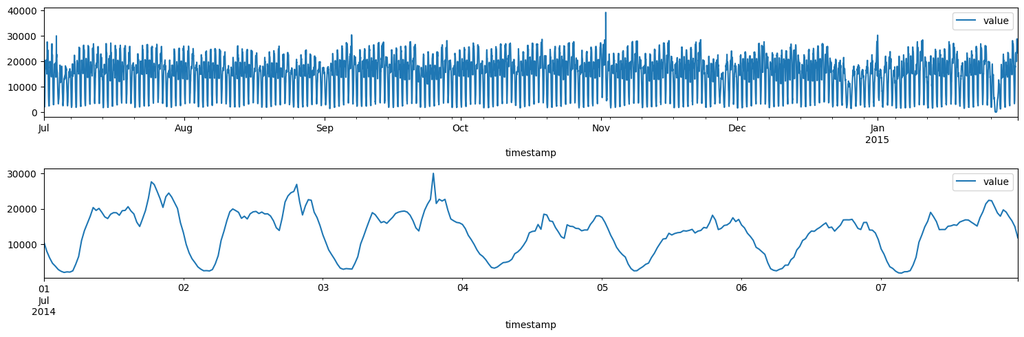

```python
_, axes = plt.subplots(nrows=2)

df.plot(ax=axes[0])
df.iloc[:7*48].plot(ax=axes[1])

plt.tight_layout()
plt.show()
```

## Fitting a SARIMA Model

Since our anomalies are specified on day level, we resample our dataset to a one-day resolution

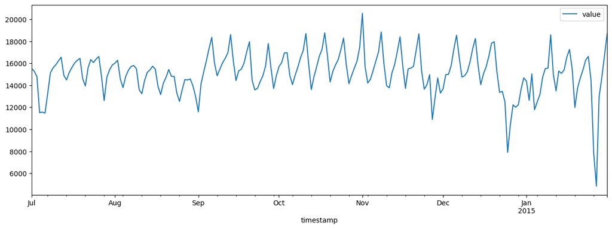

```python
df = df.resample('1D').mean()
df.plot()
plt.show()
```

## Fitting a SARIMA Model

There is no obvious trend in the data, but we can observe a seasonal pattern. Next, we try to determine good values for $p, q, P, Q$ and $m$ using the ACF and PACF plots. Some useful rules of thumb are:

- $q$: Take the first point where the ACF plot meets the significance threshold.
- $p$: Take the point where the PACF plot first meets the significance threshold.
- $m$: Take the point with the highest value in the ACF plot.
- $P$: Take $P \geq 1$ if the ACF at $m$ is positive else $0$.
- $Q$: Take $Q\geq 1$ if the ACF at $m$ is negative else $0$.
- $D$: Choose $D=1$ if the seasonal pattern (if present) is stable over time and else $D=0$.
- Usually $d+D \leq 2$ and $P+Q\leq 2$.

*Note*: If we would observe a trend in the data then we would first difference the series until the trend disappears before we compute the ACF and PACF plots. The order of differencing equals the $d$ value in our SARIMA model.

## Fitting a SARIMA Model

- We have already observed a stable seasonal pattern $\Rightarrow$ $D=1$
- We plot the ACF:

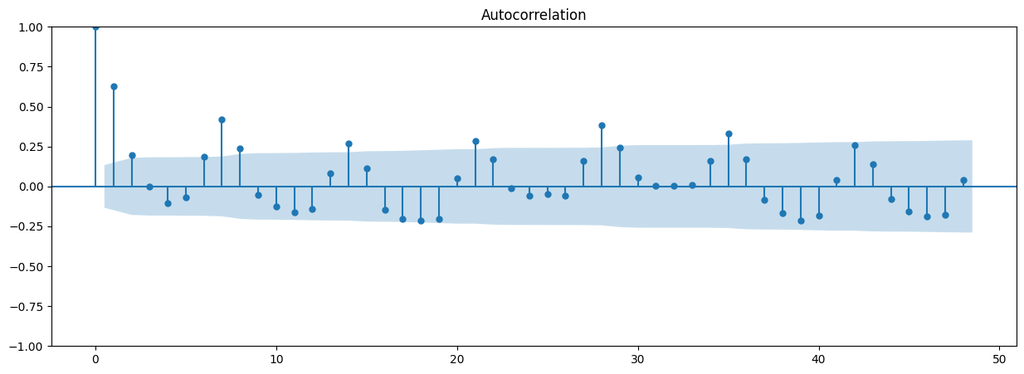

```python
fig, ax = plt.subplots()
tsaplots.plot_acf(df, lags=48, ax=ax)
plt.show()
```

**Question:** Try to determine the period of the seasonal pattern

## Fitting a SARIMA Model

We apply seasonal differencing to find a value for $q$

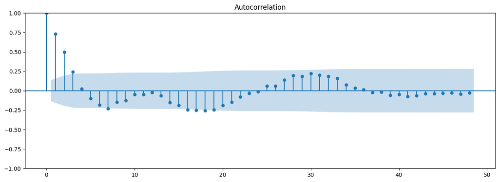

```python
fig, ax = plt.subplots()
tsaplots.plot_acf(df.diff(7).dropna(), lags=48, ax=ax)
plt.show()
```

**Question:** Try to determine the order of the moving average.

- We see in the second plot that the autocorrelation meets the significance threshold at a lag of $3$ $\Rightarrow$ $q=3$.

## Partial Autocorrelation Function

A related and also important function is the *partial autocorrelation function (pacf)*. The pacf measures the conditional correlation between a variable, and the lagged versions of itself given that we know the values of all lagged versions in between. For stationary SARIMA processes:

$\mathrm{pacf}(k) = \frac{\mathrm{Cov}(X_t, X_{t+k} \mid X_{t+1}, \ldots, X_{t+k-1})}{\sqrt{\mathrm{Var}(X_t\mid X_{t+1}, \ldots, X_{t+k-1})\mathrm{Var}(X_{t+k}\mid X_{t+1}, \ldots, X_{t+k-1})}}$

The pacf is better suited to choose values for $p$ since a purely autoregressive process of order $k$ has $\mathrm{pacf}(\ell) = 0$ for all $\ell > k$.

Next, we plot the PACF for our series.

## Fitting a SARIMA Model

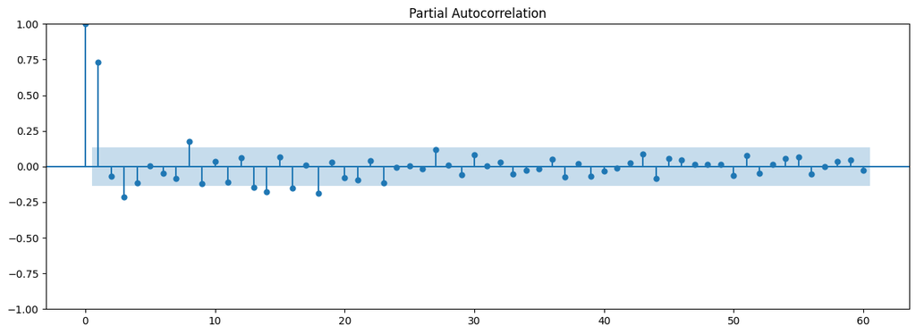

```python
fig, ax = plt.subplots()
tsaplots.plot_pacf(df.diff(7).dropna(), lags=60, ax=ax)
plt.show()
```

**Question:** Try to determine the order of the autoregressive part.

- The PACF plot falls below the significance threshold after lag $1$ $\Rightarrow$ $p=1$

We conclude that $\mathrm{SARIMA}(1,0,3)(1,1,0)_{7}$ might be a good model for our time series.

## Fitting a SARIMA Model

Finally, we fit the model on our data

```python
model = sm.tsa.statespace.SARIMAX(df, order=(1, 0, 3), seasonal_order=(1, 1, 0, 7))
result = model.fit(disp=False)
result.summary()
```

SARIMAX Results

| Dep. Variable: | value | No. Observations: | 215 |
| --- | --- | --- | --- |
| Model: | SARIMAX(1, 0, 3)x(1, 1, [], 7) | Log Likelihood | -1784.299 |
| Date: | Tue, 05 Mar 2024 | AIC | 3580.597 |
| Time: | 09:20:43 | BIC | 3600.622 |
| Sample: | 07-01-2014 | HQIC | 3588.694 |
|  | - 01-31-2015 |  |  |
| Covariance Type: | opg |  |  |

|  | coef | std err | z | P>\|z\| | [0.025 | 0.975] |
| --- | --- | --- | --- | --- | --- | --- |
| ar.L1 | 0.3844 | 0.184 | 2.094 | 0.036 | 0.025 | 0.744 |
| ma.L1 | 0.3443 | 0.195 | 1.768 | 0.077 | -0.037 | 0.726 |
| ma.L2 | 0.3175 | 0.144 | 2.202 | 0.028 | 0.035 | 0.600 |
| ma.L3 | 0.0983 | 0.102 | 0.960 | 0.337 | -0.102 | 0.299 |
| ar.S.L7 | -0.2448 | 0.033 | -7.353 | 0.000 | -0.310 | -0.180 |
| sigma2 | 1.549e+06 | 7.03e+04 | 22.039 | 0.000 | 1.41e+06 | 1.69e+06 |

| Ljung-Box (L1) (Q): | 0.93 | Jarque-Bera (JB): | 533.67 |
| --- | --- | --- | --- |
| Prob(Q): | 0.33 | Prob(JB): | 0.00 |
| Heteroskedasticity (H): | 2.52 | Skew: | -0.88 |
| Prob(H) (two-sided): | 0.00 | Kurtosis: | 10.65 |

Warnings:  
[1] Covariance matrix calculated using the outer product of gradients (complex-step).

## Fitting a SARIMA Model

We can use one step ahead prediction on our time series to perform anomaly detection. Statsmodels provides a confidence interval with the prediction based on the estimated variance of the error terms. We mark a point as anomaly if the true value falls outside the confidence interval of the prediction.

```python
prediction = result.get_prediction(start='2014-07-14')
prediction_mean = prediction.predicted_mean
prediction_ci = prediction.conf_int()
```

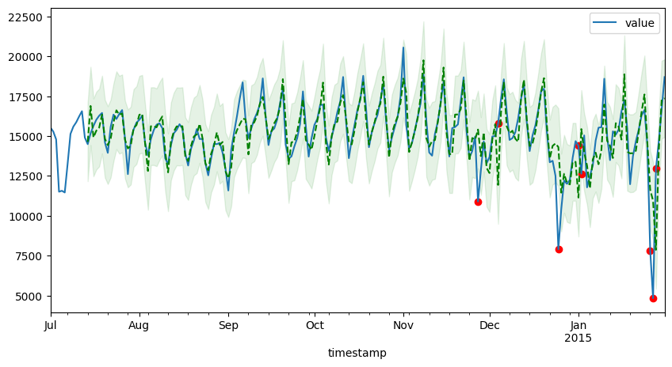

```python
_, ax = plt.subplots(figsize=(10,5))
df.plot(ax=ax)
prediction_mean.plot(style='g--', ax=ax)
ax.fill_between(prediction_ci.index, prediction_ci.iloc[:,0], prediction_ci.iloc[:,1], color='g', alpha=0.1)

threshold = (prediction_ci.iloc[:,1] - prediction_mean)
mask = (prediction_mean - df['value'].iloc[14:]).abs() > threshold
outlier = df.iloc[14:][mask]
ax.scatter(outlier.index, df.loc[outlier.index], color='r')
plt.show()
```

## Fitting a SARIMA Model

We compare the list of known anomalies with our detection

- NYC Marathon - 2014-11-02
- Thanksgiving - 2014-11-27
- Christmas - 2014-12-25
- New Years - 2015-01-01
- Snow Blizzard - 2015-01-26
- Snow Blizzard - 2015-01-27

```python
outlier
```

| timestamp | value |
| --- | --- |
| 2014-11-27 | 10899.666667 |
| 2014-12-04 | 15795.895833 |
| 2014-12-25 | 7902.125000 |
| 2015-01-01 | 14383.479167 |
| 2015-01-02 | 12639.916667 |
| 2015-01-26 | 7818.979167 |
| 2015-01-27 | 4834.541667 |
| 2015-01-28 | 12947.562500 |

**Question:** Compare our result and the known anomalies. Do you spot anything notable?

[figure not shown]

Thank you for the attention, this concludes the section of A.D. for Time Series.